# Assignment_4_Harsha

```r
P_Infected<-round(25.9/100,3)
P_Not_Infected<-round(1-P_Infected,3)
P_Inf_Pos<-round(99.7/100,3)
P_Inf_Neg<-round(1-P_Inf_Pos,3)
P_Not_Inf_Neg<-round(92.6/100,3)
P_Not_Inf_Pos<-round(1-P_Not_Inf_Neg,3)
```

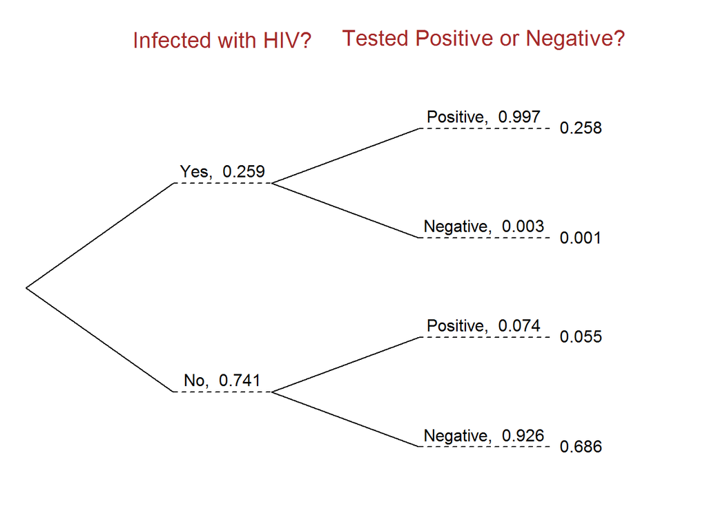

```r
#?treeDiag
#install.packages("openintro")
library(openintro)
treeDiag(c("Infected with HIV?","Tested Positive or Negative?"),c(P_Infected, P_Not_Infected), out1 = c("Yes", "No"),out2 = c("Positive", "Negative"), list(c(P_Inf_Pos, P_Inf_Neg), c(P_Not_Inf_Pos, P_Not_Inf_Neg)),col.main="Brown",SBS=TRUE,showSol=TRUE,digits=3)
```

#Solution:0.8242812

```r
0.258/(0.258+0.055)   ##Actually carrying HIV divided by ones tested positive (both carrying and not carrying)
```

```
## [1] 0.8242812
```

#Question 2: According to a 2013 Gallup poll, worldwide only 13% of employees are engaged at work (psychologically committed to their jobs and likely to be making positive contributions to their organizations). Among a random sample of 10 employees, what is the probability that 8 of them are engaged at work?

#Solution: 2.77842e-06

From question, we can understand that the random sample of 10 employees is 10 independent trials in which 8 being engaged at work is equivalent 8 success cases and 2 being failure cases

Probability of employee working ie. success is 0.13 P_Success Hence follows Binomial distribution _______________________________________________________ ##Result

Result-> (10 choose 8)*P_Success^8* (1-P_Success)^2

Code wise:We directly use dbinom function

```r
dbinom(8,10,0.13)
```

```
## [1] 2.77842e-06
```

#Question 3: Recent study: “Facebook users get more than they give”

friend requests: 40% made, 63% received at least one likes: liked 14 times, had their content “liked” 20 times, on average messages: sent 9 messages, received 12, on average tags:12% tagged a friend in a photo, but 35% tagged other findings: 25% considered power users ( give more than get) average Facebook user has 245 friends P(70 or more power user friends) = ?

n=245 p=0.25 ##Plot Inference Fixed 245 Users,with division of power user/not,probability being 0.25 and we assume they are independent

```r
#Data Initialisations

n<-245
p<-0.25
```

To find: Probability of 70 or more power-user friends among 245 ie.,sum of probabilities of each one of these outcomes 70 through 245

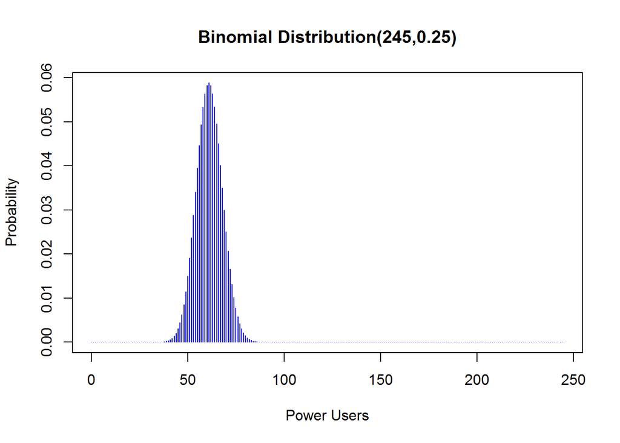

```r
probabilities <- dbinom(x = c(0:245), size = n, p)
plot(0:245, probabilities, type = "h",xlab ='Power Users',ylab='Probability',col="blue",main="Binomial Distribution(245,0.25)")
```

____________________________________________________________________________________________

##Explanation

mean, of a binomial distribution, is calculated by multiplying the number of trials by the probability of successes mean<-n*p sd<-sqrt[ n * P * ( 1 - P ) ]

```r
mean<-n*p
print(mean)
```

```
## [1] 61.25
```

```r
sd<-round(sqrt(n*p*(1-p)),2)
print(sd)
```

```
## [1] 6.78
```

61.25 power users, give or take 6.78.

Using the mean and sd let’s calculate z_score with 70 as observation point

```r
z<-(70-mean)/sd
z
```

```
## [1] 1.29056
```

Using pnorm function we calculate the probability for z-score( As we assumed binomial to be normal) But as we need above 70 , we will take complement of the users under the curve’s observation point

```r
1-pnorm(z,0,1)
```

```
## [1] 0.09842807
```

Using pre-defined method in R,which gives a more accurate value based on binomial distribution (without approximating to be a normal distribution)

```r
sum(dbinom(70:245, size = 245, p = 0.25))
```

```
## [1] 0.112763
```

##Solution:0.112763

#Question 4: According to a 2014 Gallup poll, 56% of uninsured Americans who plan to get health insurance say they will do so through a government health insurance exchange. What is the probability that in a random sample of 10 people exactly 6 plan to get health insurance through a government health insurance exchange?

From question, we can understand that the random sample of 10 people is 10 independent trials in which exactly 6 plan to get health insurance through a government health insurance is equivalent to 6 success cases and 4 being failure cases

Probability of person plan to get an insurance ie. success is 0.56 P_Success Hence follows Binomial distribution _________________________________________________________________________________________________________ ##Result Result-> (10 choose 6)*P_Success^6* (1-P_Success)^4

Code wise:We directly use dbinom function

```r
dbinom(6,10,0.56)
```

```
## [1] 0.2427494
```

#Solution:0.2427494

____________The End________________________